# Sean's Blog

## **Bar Plots and Histograms**

Following charts visualize various statistics of the data. The following are some conclusions made:

- More females survived than males
- Children (ages less than 10) had higher chance of survival
- More people that boarded in Cherbourg survived
- Large number of males in 3rd class

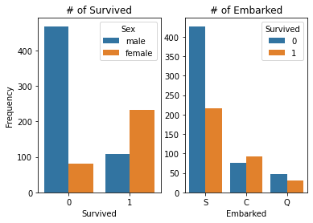

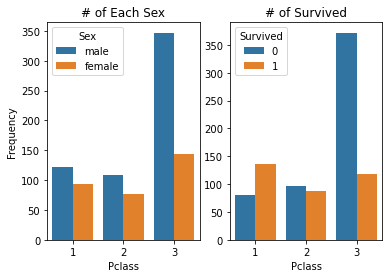

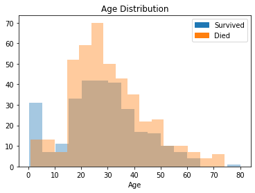

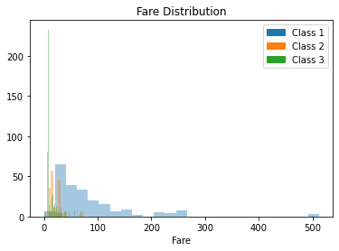

```python
plt.subplot2grid((1,2),(0,0))
sns.countplot(x='Survived',hue='Sex',data=train_raw)
plt.ylabel('Frequency')
plt.title("# of Survived")

plt.subplot2grid((1,2),(0,1))
sns.countplot(x='Embarked',hue='Survived',data=train_raw)
plt.ylabel(' ')
plt.title("# of Embarked")
plt.show()

plt.subplot2grid((1,2),(0,0))
sns.countplot(x='Pclass',hue='Sex',data=train_raw)
plt.ylabel('Frequency')
plt.title("# of Each Sex")

plt.subplot2grid((1,2),(0,1))
sns.countplot(x='Pclass',hue='Survived',data=train_raw)
plt.ylabel(' ')
plt.title("# of Survived")
plt.show()

fig, ax = plt.subplots()
sns.distplot(train_raw.Age[train_raw.Survived==1],kde=False,ax=ax, color="#1f77b4")
sns.distplot(train_raw.Age[train_raw.Survived==0],kde=False,ax=ax, color="#ff7f0e")
plt.title("Age Distribution")
plt.xlabel('Age')
red_patch = mpatches.Patch(color='#1f77b4', label='Survived')
blue_patch = mpatches.Patch(color='#ff7f0e', label='Died')
plt.legend(handles=[red_patch, blue_patch] ,loc='best')
plt.show()

fig, ax = plt.subplots()
sns.distplot(train_raw.Fare[train_raw.Pclass==1],kde=False,color="#1f77b4", ax=ax)
sns.distplot(train_raw.Fare[train_raw.Pclass==2],kde=False,color="#ff7f0e", ax=ax)
sns.distplot(train_raw.Fare[train_raw.Pclass==3],kde=False,color="#2ca02c", ax=ax)
plt.title("Fare Distribution")
patch_1 = mpatches.Patch(color='#1f77b4', label='Class 1')
patch_2 = mpatches.Patch(color='#ff7f0e', label='Class 2')
patch_3 = mpatches.Patch(color='#2ca02c', label='Class 3')
plt.legend(handles=[patch_1, patch_2, patch_3])
plt.xlabel('Fare')
plt.show()
```

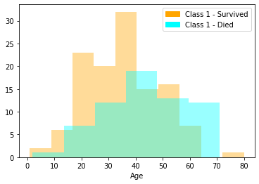

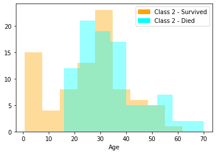

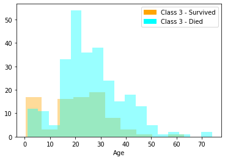

```python
#Pclass 1 Age Survival Figure
fig, ax = plt.subplots()
sns.distplot(train_raw.Age[train_raw.Survived==1][train_raw.Pclass==1],kde=False,ax=ax, color="#FFA500")
sns.distplot(train_raw.Age[train_raw.Survived==0][train_raw.Pclass==1],kde=False,ax=ax, color="#00FFFF")
red_patch = mpatches.Patch(color='#FFA500', label='Class 1 - Survived')
blue_patch = mpatches.Patch(color='#00FFFF', label='Class 1 - Died')
plt.legend(handles=[red_patch, blue_patch] ,loc='best')
#Pclass 2 Age Survival Figure
fig, ax = plt.subplots()
sns.distplot(train_raw.Age[train_raw.Survived==1][train_raw.Pclass==2],kde=False,ax=ax, color="#FFA500")
sns.distplot(train_raw.Age[train_raw.Survived==0][train_raw.Pclass==2],kde=False,ax=ax, color="#00FFFF")
red_patch = mpatches.Patch(color='#FFA500', label='Class 2 - Survived')
blue_patch = mpatches.Patch(color='#00FFFF', label='Class 2 - Died')
plt.legend(handles=[red_patch, blue_patch] ,loc='best')
#Pclass 3 Age Survival Figure
fig, ax = plt.subplots()
sns.distplot(train_raw.Age[train_raw.Survived==1][train_raw.Pclass==3],kde=False,ax=ax, color="#FFA500")
sns.distplot(train_raw.Age[train_raw.Survived==0][train_raw.Pclass==3],kde=False,ax=ax, color="#00FFFF")
red_patch = mpatches.Patch(color='#FFA500', label='Class 3 - Survived')
blue_patch = mpatches.Patch(color='#00FFFF', label='Class 3 - Died')
plt.legend(handles=[red_patch, blue_patch] ,loc='best')
```

# Filling in Missing Data

</br> <sup>1</sup> The link to Allohvk's full notebook can be found here: https://www.kaggle.com/allohvk/titanic-missing-age-imputation-tutorial-advanced

# Feature Engineering and Scaling

Various features were engineered. The following list outlines the different features and how they were calculated

- Fam_size - Family size determined by adding number of siblings and spouse and number of parents and children plus one
- Alone - Binary feature determined on whether family size is equal to one
- Ageclass - Product of age and class, idea based on user Manav Sehgal's notebook <sup>2</sup>

The age and fare features also had boxcox transformation performed on them since these features were relatively skewed. Then finally a min-max scaler was applied to boxcox features and the classAge feature.

</br> <sup>2</sup> The link to Manav Sehgal's full notebook can be found here: https://www.kaggle.com/startupsci/titanic-data-science-solutions

```python
# Dictionary with all the titles
TitleDict = {"Capt": "Officer","Col": "Officer","Major": "Officer","Jonkheer": "Royalty", \
             "Don": "Royalty", "Sir" : "Royalty","Dr": "Royalty","Rev": "Royalty", \
             "Countess":"Royalty", "Mme": "Mrs", "Mlle": "Miss", "Ms": "Mrs","Mr" : "Mr", \
             "Mrs" : "Mrs","Miss" : "Miss","Master" : "Master","Lady" : "Royalty"}

for df in dfs:
    df['Embarked']=df[['Embarked']].fillna(train_raw.mode()['Embarked'][0])
    df['Fare']=df[['Fare']].fillna(train_raw['Fare'].median())
    df['Title']=df.Name.str.extract(' ([A-Za-z]+)\.', expand=False)
    df['Title']=df.Title.map(TitleDict)
    df['Fam_size']=df['SibSp']+df['Parch']+1
    df.loc[(df.Title=='Miss')&(df.Parch!=0)&(df.Fam_size>1),'Title']='Fchild'
    df['Alone']=df['Fam_size'].apply(lambda x:1 if x==1 else 0)

age_vals = dfs[0].groupby(['Pclass','Sex','Title'])['Age'].mean()
for df in dfs:
    vals=df[df["Age"].isnull()].index.values.astype(int).tolist()
    for val in vals:
        df.loc[val,'Age']=age_vals[df.loc[val,'Pclass'],df.loc[val,'Sex'],df.loc[val,'Title']]
```

```python
train=dfs[0]
test=dfs[1]
train=train.drop(['PassengerId','Name','Cabin','Survived','Ticket'],axis=1)
test=test.drop(['PassengerId','Name','Cabin','Ticket'],axis=1)
test['Title']=test[['Title']].fillna('Mrs')
```

```python
train = pd.get_dummies(train)
test= pd.get_dummies(test)
```

```python
train['boxAge']=stats.boxcox(train['Age'])[0]
trainfare=np.array(train['Fare'])
trainfare[trainfare<=0]=0.01
train['boxFare']=stats.boxcox(trainfare)[0]

testfare=np.array(test['Fare'])
testfare[testfare<=0]=0.01

test['boxAge']=stats.boxcox(test['Age'], stats.boxcox(train['Age'])[1])
test['boxFare']=stats.boxcox(testfare, stats.boxcox(trainfare)[1])
train=train.drop(['Age','Fare'], axis=1)
test=test.drop(['Age','Fare'], axis=1)
train['Ageclass']=train['boxAge']*train['Pclass']
test['Ageclass']=test['boxAge']*train['Pclass']
train.head()
```

|  | Pclass | SibSp | Parch | Fam_size | Alone | Sex_female | Sex_male | Embarked_C | Embarked_Q | Embarked_S | Title_Fchild | Title_Master | Title_Miss | Title_Mr | Title_Mrs | Title_Officer | Title_Royalty | boxAge | boxFare | Ageclass |
| --- | --- | --- | --- | --- | --- | --- | --- | --- | --- | --- | --- | --- | --- | --- | --- | --- | --- | --- | --- | --- |
| 0 | 3 | 1 | 0 | 2 | 0 | 0 | 1 | 0 | 0 | 1 | 0 | 0 | 0 | 1 | 0 | 0 | 0 | 13.748924 | 2.382205 | 41.246772 |
| 1 | 1 | 1 | 0 | 2 | 0 | 1 | 0 | 1 | 0 | 0 | 0 | 0 | 0 | 0 | 1 | 0 | 0 | 22.047627 | 6.431555 | 22.047627 |
| 2 | 3 | 0 | 0 | 1 | 1 | 1 | 0 | 0 | 0 | 1 | 0 | 0 | 1 | 0 | 0 | 0 | 0 | 15.909810 | 2.510599 | 47.729431 |
| 3 | 1 | 1 | 0 | 2 | 0 | 1 | 0 | 0 | 0 | 1 | 0 | 0 | 0 | 0 | 1 | 0 | 0 | 20.553768 | 5.811290 | 20.553768 |
| 4 | 3 | 0 | 0 | 1 | 1 | 0 | 1 | 0 | 0 | 1 | 0 | 0 | 0 | 1 | 0 | 0 | 0 | 20.553768 | 2.533385 | 61.661304 |

```python
min_max_scaler = preprocessing.MinMaxScaler()
train[['boxAge','boxFare','Ageclass']] = min_max_scaler.fit_transform(train[['boxAge','boxFare','Ageclass']])
test[['boxAge','boxFare','Ageclass']] = min_max_scaler.fit_transform(test[['boxAge','boxFare','Ageclass']])
```

# Machine Learning Models

```python
X_train, X_test, y_train, y_test = train_test_split(train, y_train, test_size=0.2, random_state=42)
```

## Logistic Regression

```python
LogReg=LogisticRegression()
LogReg.fit(X_train,y_train)
log_reg_s=LogReg.score(X_test,y_test)
print(log_reg_s)
model_comp=pd.DataFrame({'ML Model':'Log_Reg','Score':[log_reg_s]})
predict=LogReg.predict(test)
results=pd.DataFrame({'PassengerId':test_raw['PassengerId'],'Survived':pd.Series(predict)})
results.to_csv('resultslogreg.csv',index=False)
```

```
0.8212290502793296
```

## Random Forest

```python
from sklearn.ensemble import RandomForestClassifier
model = RandomForestClassifier(n_estimators=100,max_depth=5)
model.fit(X_train, y_train)
Rand_For_S=model.score(X_test, y_test)
model_comp=model_comp.append({'ML Model':'Rand_For','Score':Rand_For_S},ignore_index=True)
print(Rand_For_S)
```

```
0.8268156424581006
```

```python
predict = model.predict(test)
results=pd.DataFrame({'PassengerId':test_raw['PassengerId'],'Survived':pd.Series(predict)})
results.to_csv('resultsrt.csv',index=False)
```

## XGB

```python
from xgboost import XGBClassifier
my_modelxg = XGBClassifier(n_estimators=1000, learning_rate=0.1, subsample=0.9, colsample_bytree = 0.9)
my_modelxg.fit(X_train, y_train,
             early_stopping_rounds=5,
             eval_set=[(X_test, y_test)],
             verbose=False)
```

```
XGBClassifier(base_score=0.5, booster='gbtree', colsample_bylevel=1,
              colsample_bynode=1, colsample_bytree=0.9, gamma=0, gpu_id=-1,
              importance_type='gain', interaction_constraints='',
              learning_rate=0.1, max_delta_step=0, max_depth=6,
              min_child_weight=1, missing=nan, monotone_constraints='()',
              n_estimators=1000, n_jobs=0, num_parallel_tree=1, random_state=0,
              reg_alpha=0, reg_lambda=1, scale_pos_weight=1, subsample=0.9,
              tree_method='exact', validate_parameters=1, verbosity=None)
```

```python
predict_cv = my_modelxg.predict(X_test)


from sklearn.metrics import accuracy_score
cv_score=accuracy_score(y_test,predict_cv)
model_comp=model_comp.append({'ML Model':'XGB','Score':cv_score},ignore_index=True)
print ("CV Score: ",cv_score)
```

```
CV Score:  0.8547486033519553
```

```python
predict = my_modelxg.predict(test)
results=pd.DataFrame({'PassengerId':test_raw['PassengerId'],'Survived':pd.Series(predict)})
results.to_csv('resultsXG.csv',index=False)
```

# Conclusion

The model with the highest cross validation score was the XGB model with 85.47% accuracy. However, after submitting all three solutions to the competition the random forest achieved the highest accuracy with 78.71% with XGB achieving 78.47% and the logistic regression achieving 77.75%

```python
print(model_comp.sort_values(by=['Score'],ascending=False))
```

```
   ML Model     Score
2       XGB  0.854749
1  Rand_For  0.826816
0   Log_Reg  0.821229
```